# Hypothesis Testing

In this chapter, we’ll explore hypothesis tests, which is a framework used to rigorously evaluate competing ideas and claims.

### Needed packages

Let’s load all the packages needed for this chapter.

```r
library(tidyverse)
library(moderndive)
```

## Ingot example

Let’s start with a concrete example.

### Has the cracking rate improved?

Ingots are huge pieces of metal, sometimes weighing more than 50,000 pounds, made in a giant mold. They must be cast in one large piece for use in fabricating large structural parts for cars and planes. As the liquid metal cools, cracks can develop on the surface of the ingot, which can propagate into the zone required for the part, compromising its integrity. Airplane manufacturers insist that metal for their planes be defect-free, so the ingot must be made over if any cracking is detected.

Even though the metal from the cracked ingot is recycled, the cost runs into the tens of thousands of dollars to recast an ingot, not to mention the energy waste. It’s estimated that about 50% of aluminum ingots need to be recast because of cracking. In an attempt to reduce the cracking proportion, the plant engineers and chemists recently tried out some changes in the casting process. Since then, 400 ingots have been cast and only 180 of them have cracked (this is 45%). Has the new method worked? Has the cracking rate really decreased, or was 45% just due to randomness?

### Rephrase using statistical language

We can treat the 400 ingots cast with the new method as a random sample. We know that each random sample will have a somewhat different proportion of cracked ingots. Is the 45% we observe merely a result of natural sampling variability, or is this lower cracking rate strong enough evidence to assure management that the true cracking rate now is really below 50%?

In other words, we want to know if the changes made by the engineers have lowered the cracking rate from 50%. Humans are natural skeptics, so to test whether the changes have worked, we’ll assume that they haven’t. *We’ll make the hypothesis that the cracking rate is still 50% and see if the data can convince us otherwise.*

People want answers to questions like these all the time. Has the president’s approval rating changed since last month? Has teenage smoking decreased in the past five years? Is the global temperature increasing? Did the Super Bowl ad we bought actually increase sales? To answer such questions, we introduce the method of *hypothesis testing*.

### Terminology & Notation

In order to understand the procedure of hypothesis testing, we begin by providing some vocabulary and notation that we will use throughout the remainder of this course.

1. **Hypothesis**: According to the Webster’s Unabridged Dictionary, Hypothesis n.: l. (Hypotheses) is a supposition; a proposition or principle which is supposed or taken for granted, in order to draw a conclusion or inference for proof of the point in question; something not proved, but assumed for the purpose of argument.

   In statistics, a hypotheses is a statement about the value of an unknown population parameter. In the ingot example, our pupulation parameter of interest is the cracking rate $p$. This starting hypothesis to be tested is called the null hypothesis— null because it assumes that nothing has changed. We denote it $H_0$. It specifies a parameter value—here that the cracking rate is 0.50 — which we usually write in the form $H_0$: parameter = hypothesized value. So, for the ingots we would write: $H_0: p = 0.50$.
2. **Alternative hypothesis**: The alternative hypothesis, which we denote $H_A$, contains the values of the parameter that we consider plausible if we reject the null hypothesis. Our null hypothesis is that $p = 0.50$. What’s the alternative? Management is interested in reducing the cracking rate, so their alternative is $H_A: p < 0.50$.
3. **Hypothesis test**: A hypothesis test consists of a test between two competing hypotheses: (1) a null hypothesis $H_0$ versus (5) an alternative hypothesis $H_A$. In the ingot example, an appropriate hypothesis test would be:

$$H_0: \text{the cracking rate p is 0.50 (p = 0.50)} \\
H_A: \text{the cracking rate p is less than 0.50 (p < 0.50)}$$

While it would not be wrong in principle to reverse the two, it is a convention in statistical inference that the null hypothesis is set to reflect a “null” situation where “nothing is going on.” As we discussed earlier, in this case, $H_0$ corresponds to there being no improvement from using the new method. Furthermore, we set $H_A$ to be that there is improvment form using the new method, a subjective choice reflecting a prior suspicion we have that this is the case.

4. **Test statistic**: a test statistic is a sample statistic used for hypothesis testing. Note that a sample statistic is merely a summary statistic based on a sample of observations. Recall we saw in previous chapters that a summary statistic takes in many values and returns only one. Here, the test statistic would be the proportion of cracked ingots.
5. **Observed test statistic**: the observed test statistic is the value of the test statistic that we observed in real life. In our case, this value is 45%.
6. **Null distribution**: the null distribution is the sampling distribution of the test statistic assuming the null hypothesis $H_0$ is true. Ooof! That’s a long one! Let’s unpack it slowly. The key to understanding the null distribution is that the null hypothesis $H_0$ is assumed to be true. We’re not saying that $H_0$ is true at this point, we’re only assuming it to be true for hypothesis testing purposes. In our case, this corresponds to our hypothesized universe of the cracking rate is 0.50. Assuming the null hypothesis $H_0$ also stated as “under $H_0$”, how does the test statistic vary due to sampling variation? In our case, how will the sample proportions vary due to sampling under$H_0$?

Recall from Wednesday that distributions displaying how sample statistic vary due to sampling variation are called sampling distributions. The only additional thing to keep in mind about null distributions is that they are sampling distributions assuming the null hypothesis $H_0$ is true.

### Key question: what would the null distribution look like?

Remember in the ingot example, we would like to know if 45% crack rate in the ingot example we observe is merely a result of natural sampling variability or is this lower crack rate strong enough evidence to assure management that the true cracking rate now is really below 50%. The key question here is whether the 45% cracking rate could reasonly occur under the assumption that the crack rate is 50%. In other words, we would like to know how often we would observe results like the 45% crack rate under the null distribution, and therefore determine whether or not in the data we observed are consistent with the null hypothesis.

One way to get the sampling distribution of our test statistic if the null hypothesis is true is by simulating (as we did in the M&M activity) the selection process of 400 ingots over and over, assuming the cracking rate is 50%.

Theoretically, you *could* design a sampling procedure by flipping a coin 400 times, record the number of heads that you obtain, which represents how of 400 hypothetical ingots are cracked if they are picking at random with a 0.50 cracking rate. You will then repeat this step (which I mean flipping coin 400 times) many many times and study the sampling distribution of the number of heads in 400 tosses…I’m sorry,my friend. That doesn’t sound very fun to me. So let’s simulate this random selection process using R.

### Sampling with R

First, let’s perform the virtual analog of flipping a coin 400 times.

```r
data.frame(
  count_head = rbinom(n = 1, size = 400, prob = 0.5)
)
```

```
##   count_head
## 1        205
```

Here’s a brief overview of how this code works:

- The `rbinom` function simulates flipping a coin 400 times and counts the number of heads that came up.
- The `binom` in the name of this function refers to the binomial distribution. The binomial distribution is just the name statisticians have given to describe how often different numbers of heads come up when you flip a coin a certain number of times. We’ll talk about this distribution next week.
- The `r` in the name of this function describes the fact that it randomly generates values from a binomial distribution.
- The `rbinom` function has three arguments, describing how the coin flipping should be done:
  1. `n` tells R how many times to repeat the experiment (just once for now)
  2. `size` tells R how many ingots are included in each run of the experiment – 400
  3. `prob` tells R how likely each baby is to choose the friendly toy – we set this to 0.5 because we’re working under the null model where ingots are equally likely to crack.

The point of using R was to make it easy to repeat the simulation many times. To perform 1000 simulations of the experiment, all under the null hypothesis that the crack rate is 0.50. One way to do this would be by changing the argument n from 1 to 1000.

```r
sample_1000 <- data.frame(
  count_head = rbinom(n = 1000, size = 400, prob = 0.5)
)

head(sample_1000)
```

```
##   count_head
## 1        211
## 2        200
## 3        195
## 4        198
## 5        200
## 6        180
```

Now let’s compute the crack rate

```r
sample_1000_prop <- sample_1000 %>%
  mutate(sample_crack_rate = count_head/400)

head(sample_1000_prop)
```

```
##   count_head sample_crack_rate
## 1        211             0.527
## 2        200             0.500
## 3        195             0.487
## 4        198             0.495
## 5        200             0.500
## 6        180             0.450
```

It’s not too helpful to just look at the list of simulated numbers. Let’s make a plot of the results and count how many of our simulated experiments (assuming the null hypothesis was true) resulted in different rates of cracked ingots.

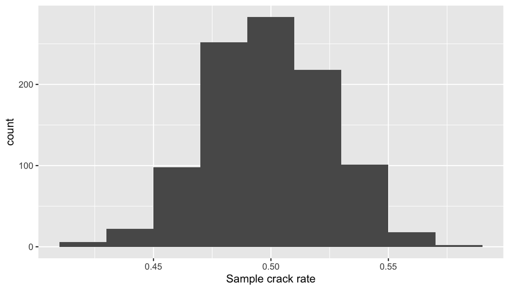

```r
ggplot(data = sample_1000_prop, mapping = aes(x = sample_crack_rate)) +
  geom_histogram(binwidth = 0.02) +
  labs(x = "Sample crack rate")
```

Base on this simulation, it would be very surprising, if the ingots will equally crack using the new method, and the 45% crack rate would not be just by chance.

```r
p <- sample_1000_prop %>%
  count(sample_crack_rate < 0.45)

p
```

```
## # A tibble: 2 x 2
##   `sample_crack_rate < 0.45`     n
##   <lgl>                      <int>
## 1 FALSE                        975
## 2 TRUE                          25
```

### P-values

The p-value quantifies this probability – what proportion had a more “extreme” result? Here, extreme is defined in terms of the alternative hypothesis $H_A$ that the new method improves the crack rate. We will see the definition of probability in the next chapter, but for now think probability as some long-run proportion. We can approximate a probability empirically by simulating the random process a large number of times and determining the proportion of times that the event happens. This is exactly what we did for computing the p-value.

**Summary** A small p-value casts doubt on the null model/hypothesis used to perform the calculation (in this case, that crack rate is 0.50)

- A p-value of .10 or less is generally considered to be some evidence against the null model/hypothesis.
- A p-value of .05 or less is generally considered to be fairly strong evidence against the null model/hypothesis.
- A p-value of .01 or less is generally considered to be very strong evidence against the null model/hypothesis.
- A p-value of .001 or less is generally considered to be extremely strong evidence against the null model/hypothesis.

### Decision errors

Hypothesis tests are not flawless. Just think of the court system: innocent people are sometimes wrongly convicted and the guilty sometimes walk free. Similarly, data can point to the wrong conclusion. However, what distinguishes statistical hypothesis tests from a court system is that our framework allows us to quantify and control how often the data lead us to the incorrect conclusion.

There are two competing hypotheses: the null and the alternative. In a hypothesis test, we make a statement about which one might be true, but we might choose incorrectly. There are four possible scenarios in a hypothesis test, which are summarized below.

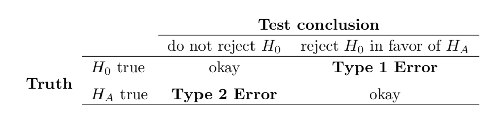

Descision error

**Example** In a US court, the defendant is either innocent ($H_0$) or guilty ($H_A$). What does a Type 1 Error represent in this context? What does a Type 2 Error represent?

If the court makes a Type 1 Error, this means the defendant is innocent ($H_0$ true) but wrongly convicted. A Type 2 Error means the court failed to reject $H_0$ (i.e. failed to convict the person) when she was in fact guilty ($H_A$ true).

**Example** How could we reduce the Type 1 Error rate in US courts? What influence would this have on the Type 2 Error rate?

To lower the Type 1 Error rate, we might raise our standard for conviction from “beyond a reasonable doubt” to “beyond a conceivable doubt” so fewer people would be wrongly convicted. However, this would also make it more difficult to convict the people who are actually guilty, so we would make more Type 2 Errors.